# Eco 602 Final Project

Final Project

Michelle Marasco

10/15/2020

# Introduction

This page will review the R code that can be useful in statistical exploration and analysis, and some examples of the implementation of this code.

Functions for data structure, numerical data exploration, graphical data exploration, distributions and others will be covered. This page can serve as both a primer in R and a reference for future statistical analyses.

# Functions 1: Data Structure Functions

## `c()`

The function `c()` *combines* or *concatenates* its arguments into a vector (a 1-dimensional data structure consisting of 1 or more elements).

- All of the elements must be of the same *type*.
  - I can’t combine character and numeric types in the same call to `c()`

Here’s two examples using numeric and character data types:

```r
# Create a vector of numbers:
num_vec  = c(1, 4, 8, 9, 13)

# Create a vector of characters:
char_vec = c("a", "fish", "data is cool")
```

I can show the contents of a vector by typing the name of the vector, or using the `print()` function.

```r
# Typing the name of the vector into the console prints the contents
num_vec
```

```
## [1]  1  4  8  9 13
```

```r
# The print() function accomplishes the same task:
print(char_vec)
```

```
## [1] "a"            "fish"         "data is cool"
```

## `data.frame()`

A data frame contains columns and rows, where each column contains the same number of items. I can create a data frame using the function `data.frame()`

- Rows must be of the same length
- Data stored can be factor, numeric, or character type
- Columns must be of the same data type

The data frame can be defined by defining each column, as shown below:

```r
## build a data frame from scratch

dat_1 <- data.frame(
  letters = c("f", "t", "w"),
  numbers_1 = c(42,6, 31415956))

## I can print the contents by typing the name of the data frame

dat_1
```

```
##   letters numbers_1
## 1       f        42
## 2       t         6
## 3       w  31415956
```

Some ways to subset a data frame:

- If I know the name of a column, I can use `$`

```r
## Here I will use subset a column by name

dat_1$letters
```

```
## [1] "f" "t" "w"
```

- You can also subset a data frame, using `subset()` !

```r
## Creating a subset using subset()

sub_1 <- subset(dat_1, letters == "f")

sub_1
```

```
##   letters numbers_1
## 1       f        42
```

To access a particular location within a data frame, I can use square brackets!

```r
## access a location within a dataframe

dat_1[3,2] ##Accesses location in the data frame at row 3, column 2
```

```
## [1] 31415956
```

Don’t forget that the Index starts at 1!!

## `matrix()`

A matrix is a two dimensional data structure that can be created using the function `matrix()`.

A matrix has a defined dimension and must be comprised of a single data type.

- a matrix may be created from a vector by applying a dimension

```r
## Create a matrix from scratch

new_matrix <- matrix(1:18, nrow = 6, ncol = 3)

## the first argument is the data for the matrix
## nrow and ncol define the dimensions, only one is required

##display new matrix

new_matrix
```

```
##      [,1] [,2] [,3]
## [1,]    1    7   13
## [2,]    2    8   14
## [3,]    3    9   15
## [4,]    4   10   16
## [5,]    5   11   17
## [6,]    6   12   18
```

Square brackets can also be used on a matrix to access a specific location:

```r
## access the value at row four and column three of the new matrix

new_matrix[4,3]
```

```
## [1] 16
```

## `length()`

The function `length()` either retrieves or sets the length of an object.

```r
## Use length() to retrieve a length

vect <- c(1:18)
length(vect)
```

```
## [1] 18
```

```r
## Use length() to set the length
## Establish and print vector

vect <- c(1:18)
vect
```

```
##  [1]  1  2  3  4  5  6  7  8  9 10 11 12 13 14 15 16 17 18
```

```r
## set the length


length(vect) <- 9
vect
```

```
## [1] 1 2 3 4 5 6 7 8 9
```

## `nrow()`

The function `nrow()` either sets or retrieves the number of rows in a matrix:

```r
##nrow() can set the rows:
matrix <- matrix(18:35, nrow = 6)
matrix
```

```
##      [,1] [,2] [,3]
## [1,]   18   24   30
## [2,]   19   25   31
## [3,]   20   26   32
## [4,]   21   27   33
## [5,]   22   28   34
## [6,]   23   29   35
```

```r
##and nrow() can retrieve the rows:

nrow(matrix)
```

```
## [1] 6
```

## `ncol()`

The function `ncol()` either sets or retrieves the number of columns in a matrix:

```r
## ncol() can set the columns:

matrix <- matrix(18:35, ncol = 6)
matrix
```

```
##      [,1] [,2] [,3] [,4] [,5] [,6]
## [1,]   18   21   24   27   30   33
## [2,]   19   22   25   28   31   34
## [3,]   20   23   26   29   32   35
```

```r
## and ncol() can retrieve the columns:

ncol(matrix)
```

```
## [1] 6
```

## `dim()`

To create a matrix from a vector, use the function `dim()`:

```r
## To create a matrix from a vector, first establish the vector:

vect <- c(1:18)

## Then apply dimension using dim()

dim(vect) <- c(3,6)

vect
```

```
##      [,1] [,2] [,3] [,4] [,5] [,6]
## [1,]    1    4    7   10   13   16
## [2,]    2    5    8   11   14   17
## [3,]    3    6    9   12   15   18
```

Similar to `length()`, `dim()` can also be used to retrieve the dimensions of something:

```r
matrix <- matrix(18:35, ncol = 6)

dim(matrix)
```

```
## [1] 3 6
```

# Functions 2: Numerical Data Exploration

## `summary()`

To get a brief synopsis of an object, I can use the function `summary()`:

```r
## load the palmerpenguins package
require(palmerpenguins)

## demonstrate
summary(penguins)
```

```
##       species          island    bill_length_mm  bill_depth_mm
##  Adelie   :152   Biscoe   :168   Min.   :32.10   Min.   :13.10
##  Chinstrap: 68   Dream    :124   1st Qu.:39.23   1st Qu.:15.60
##  Gentoo   :124   Torgersen: 52   Median :44.45   Median :17.30
##                                  Mean   :43.92   Mean   :17.15
##                                  3rd Qu.:48.50   3rd Qu.:18.70
##                                  Max.   :59.60   Max.   :21.50
##                                  NA's   :2       NA's   :2
##  flipper_length_mm  body_mass_g       sex           year
##  Min.   :172.0     Min.   :2700   female:165   Min.   :2007
##  1st Qu.:190.0     1st Qu.:3550   male  :168   1st Qu.:2007
##  Median :197.0     Median :4050   NA's  : 11   Median :2008
##  Mean   :200.9     Mean   :4202                Mean   :2008
##  3rd Qu.:213.0     3rd Qu.:4750                3rd Qu.:2009
##  Max.   :231.0     Max.   :6300                Max.   :2009
##  NA's   :2         NA's   :2
```

This can be very useful in an initial exploration of your data

## `mean()`

The `mean()` function can be used to retrieve the mean of a set of data:

```r
## load the palmerpenguins package
require(palmerpenguins)


##demonstrate
## the argument na.rm removes NA values in this calculation

mean(penguins$flipper_length_mm, na.rm = TRUE)
```

```
## [1] 200.9152
```

## `sd()`

The `sd()` function calculates standard deviation:

```r
## load the palmerpenguins package
require(palmerpenguins)

## demonstrate
## the argument na.rm removes NA values in this calculation

sd(penguins$flipper_length_mm, na.rm = TRUE)
```

```
## [1] 14.06171
```

# Functions 3: Graphical Data Exploration

See the final project description for a list of the required functions.

## `plot()`

I can use `plot()` to create scatterplots!

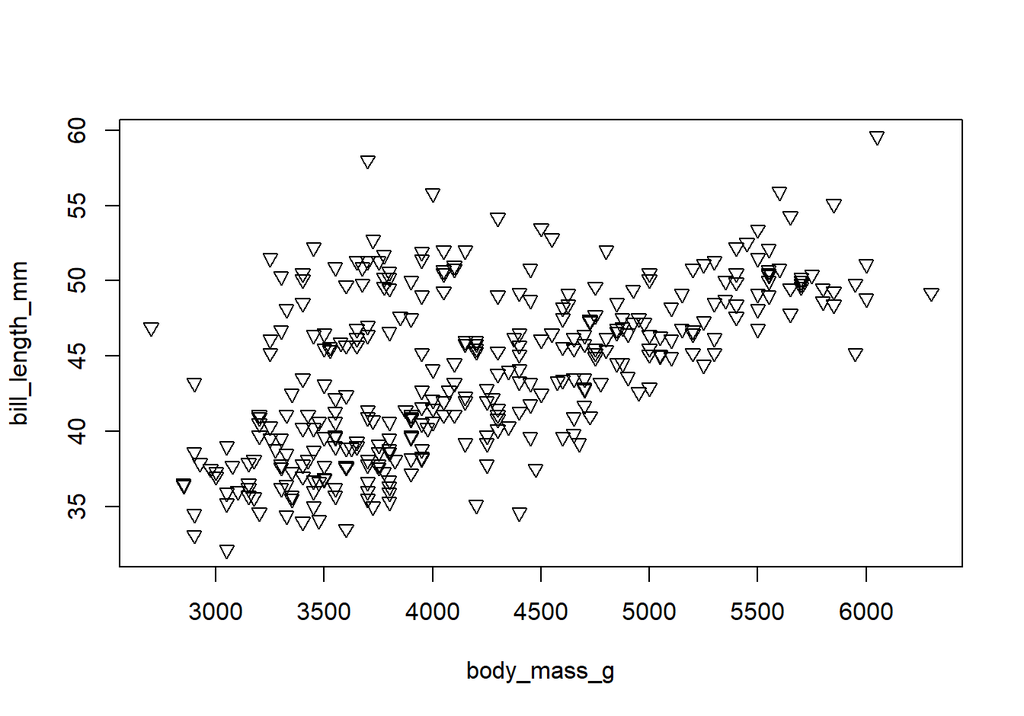

```r
## load the penguins package:
require(palmerpenguins)

## using formula notation:
## I can use the pch argument to change the symbol

plot(
  bill_length_mm ~ body_mass_g,
  data = penguins,
  pch = 6)
```

## `boxplot()`

The function `boxplot()` can be used to create boxplots!

- This can be used to plot both conditional and simple boxplots:

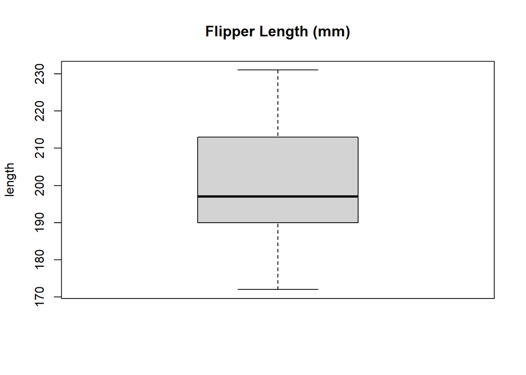

```r
## Load the palmerpenguins package:
require(palmerpenguins)

## a single boxplot:
boxplot(penguins$flipper_length_mm,
        main = "Flipper Length (mm)",
        ylab = "length")  ## here the main and ylab arguments are providing labels
```

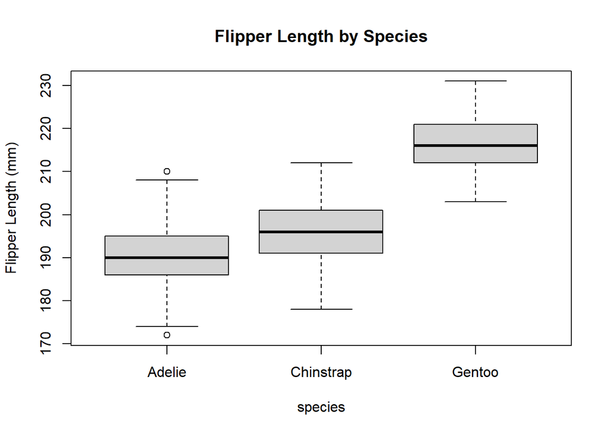

```r
## A conditional boxplot :
boxplot(flipper_length_mm ~ species, data = penguins,
        ## the first argument tells it which data to plot and which
        ## to condition it by, using the ~ (tilda)
        main = "Flipper Length by Species",
        ## again, labels
        ylab = "Flipper Length (mm)")
```